# Exclusão de outliers com PCA

Iara Souza e Clovis F Reis

2022-08-12

# Considerações Gerais

A PCA (Principal Components Analysis) é um procedimento que visa diminuir a dimensionalidade de um problema complexo, agrupando vários componentes iniciais em um único modelo simplificado, capaz de explicar a maior parte da variância dos dados originais.

Também permite uma análise preliminar dos dados, onde é possível identificar eventuais outliers. O gráfico da PCA normalmente correlaciona as duas componentes principais, e nele os outliers podem ser facilmente identificáveis como pontos no gráfico bastante distante dos demais. Isso indica que a variância nesses pontos é determinada por outros fatores que não sejam as principais componentes.

Da mesma forma, é possível identificar o comportamento de variáveis nominais em função dos componentes numéricos dos dados. Se uma variável nominal influencia na variância, os pontos relativos às observações desta variável tenderão a estar agrupados em clusteres.

Para efeito dos gráficos abaixo será utilizada a seguinte convenção:

- juntos - j
- semitandem - st
- separados - s
- tandem - t

# Normalização

Como medida preliminar, foi realizada a normalização dos dados a fim de homogeinizar a variância entre as diversas variáveis. Para tanto, todas as unidades de medida foram transformadas em função do z-score, ou seja, todas as unidades são computadas em termos de número de desvios padrão a partir da média de cada variável.

# Análise dos dados

## PCA utilizando a média das replicatas

Foi realizada a PCA tomando como componentes as média dos resultados das replicatas de cada paciente.

```r
#inicio ----
#PCA em M1
pca <- list()
gPca <- list()
gEv <- list()
gCr <- list()

#PCA em M1
ret<-trataMedia(m1)
gPca[[1]] <- ret[[1]]
pca[[1]] <- ret[[2]]

#PCA em M2
ret<-trataMedia(m2)
gPca[[2]]<-ret[[1]]
pca[[2]]<-ret[[2]]

gEv[[1]] <- fviz_eig(pca[[1]], addlabels=TRUE)
gEv[[2]] <- fviz_eig(pca[[2]], addlabels=TRUE)
```

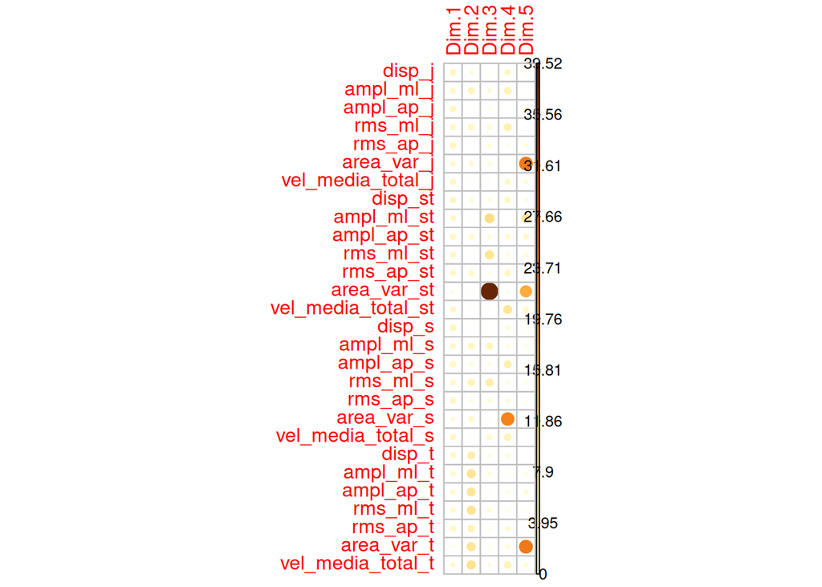

Composição das componentes principais em M1.

```r
variaveis=get_pca_var(pca[[1]])
gCr[[1]] <- corrplot(variaveis$contrib, is.corr=FALSE)
```

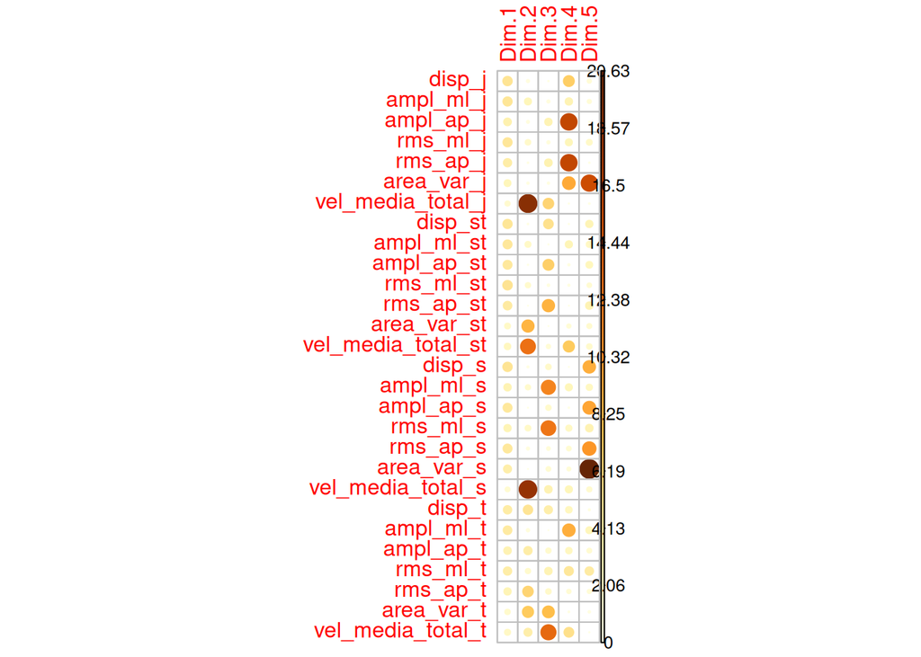

Composição das componentes principais em M2.

```r
variaveis=get_pca_var(pca[[2]])
gCr[[2]] <- corrplot(variaveis$contrib, is.corr=FALSE)
```

```r
#usar para ver maiores detalhes das componentes
# variaveis$coord
# variaveis$contrib
# variaveis$cos2
```

### Participação das componentes na explicação da variância

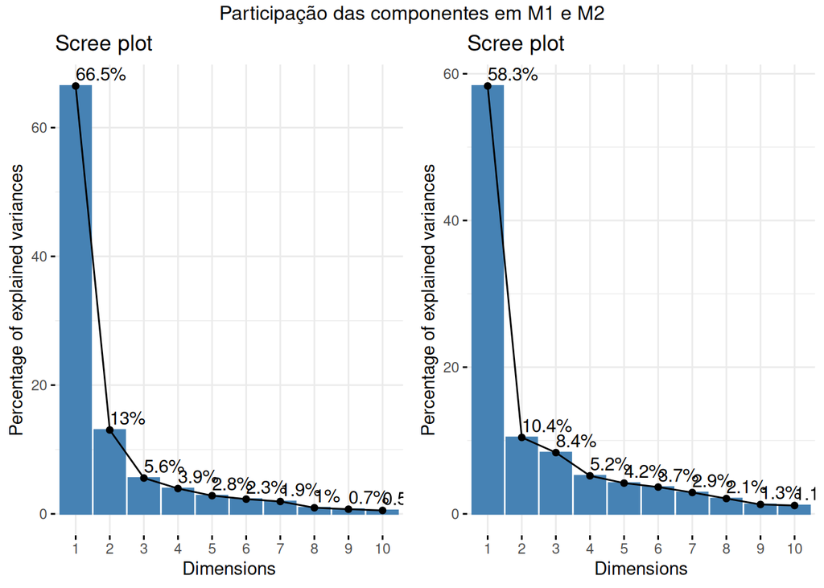

Participação de cada componente na explicação da variância.

```r
grid.arrange(grobs = gEv[1:2], ncol=2,top="Participação das componentes em M1 e M2")
```

### PCA das usando as médias em M1 e M2

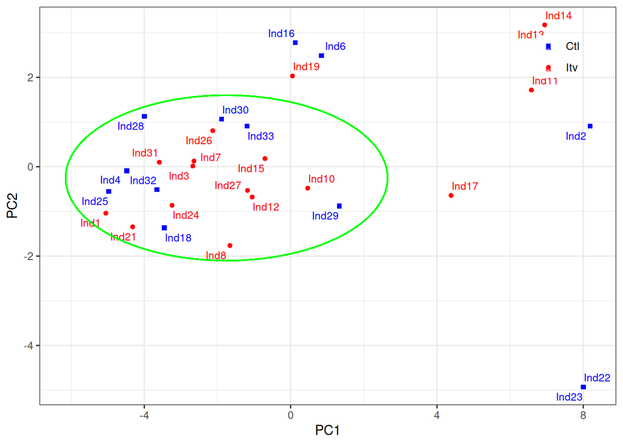

Gráfico das duas principais componentes em M1.

```r
gPca[[1]]+
  geom_ellipse(aes(x0 = -1.75, y0 = -0.25, a = 4.4, b = 1.85, angle = 0),
                       color = 'green')
```

Na PCA de M1, podemos notar que:

- Não há uma clusterização clara entre Controle e Intervenção neste primeiro momento, o que é esperado, já que, em tese, ambos os grupos devem apresentar condição similar;
- Há um pequeno agrupamento de amostras, demarcada pela elipse verde, que apresentam resultados similares;
- Os pacientes Ind2, Ind6, Ind9, Ind11, Ind13, Ind14, Ind16, Ind17, Ind22 e Ind23 apresentam uma variância nos dados não prevista pelas principais componente, sendo candidatos a uma eventual remoção do dataset.

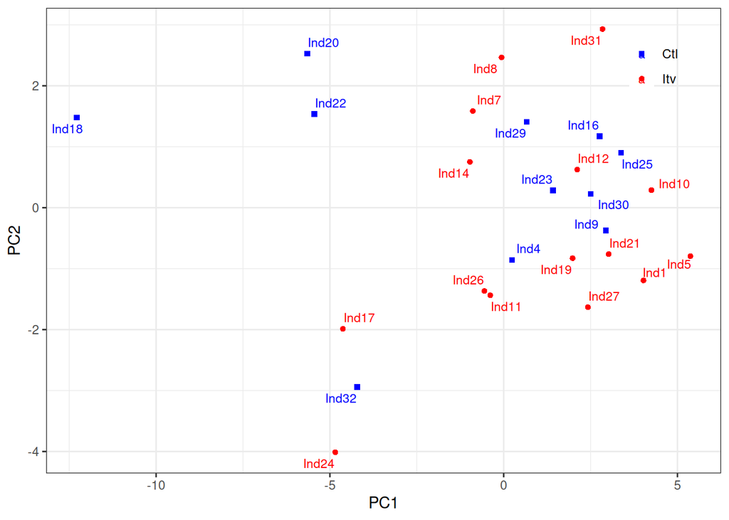

Gráfico das duas principais componentes em M2.

```r
gPca[[2]]
```

Já na PCA de M2, podemos notar que ainda não há uma clusterização clara entre Controle e Intervenção. Isso contraria o esperado, já que, após o tratamento deveria haver uma separação mais clara entre os grupos.

## PCA utilizando todas as replicatas

Também foi realizada a PCA tomando como componentes os resultados obtidos em cada uma das replicatas dos pacientes, de forma independente.

```r
# Utilizando todas os dados disponíveis
#PCA em M1
pca <- list()
gPca <- list()
gEv <- list()
gCr <- list()
ret<-trataTodos(m1)
gPca[[1]] <- ret[[1]]
pca[[1]] <- ret[[2]]

#PCA em M2
ret<-trataTodos(m2)
gPca[[2]]<-ret[[1]]
pca[[2]]<-ret[[2]]

gEv[[1]] <- fviz_eig(pca[[1]], addlabels=TRUE)
gEv[[2]] <- fviz_eig(pca[[2]], addlabels=TRUE)
```

### Participação das componentes na explicação da variância

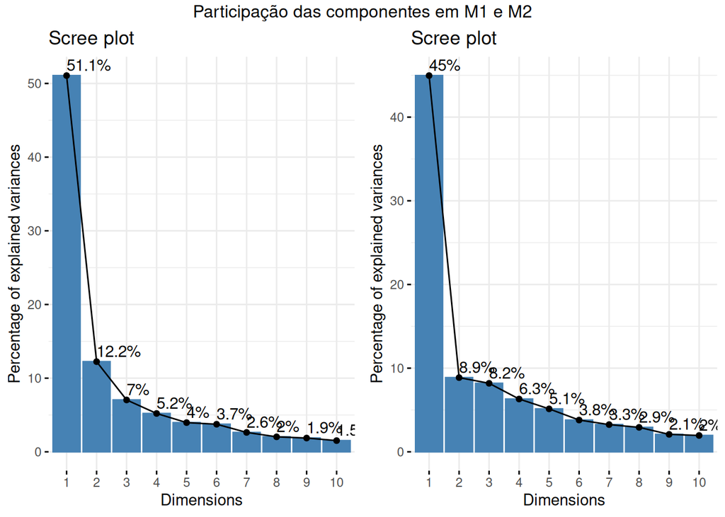

Participação de cada componente na explicação da variância.

```r
grid.arrange(grobs = gEv[1:2], ncol=2,top="Participação das componentes em M1 e M2")
```

### PCA das usando todas as replicatas em M1 e M2

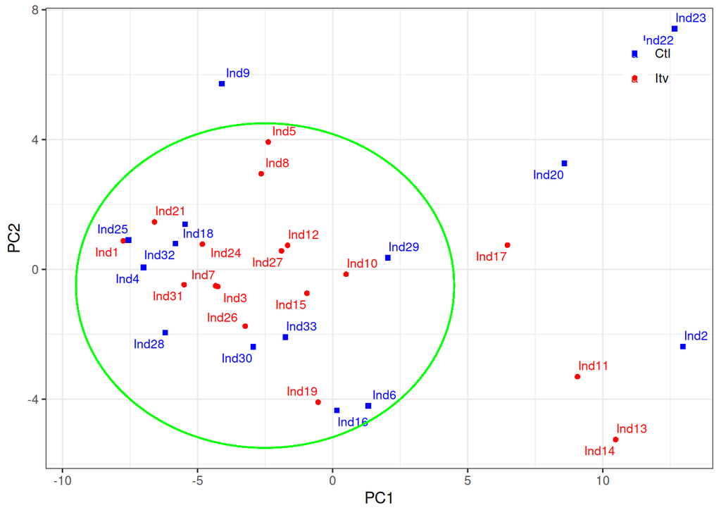

Gráfico das duas principais componentes em M1.

```r
gPca[[1]] +
   geom_ellipse(aes(x0 = -2.5, y0 = -0.5, a = 7, b = 5, angle = 0),
                      color = 'green')
```

Aqui podemos notar que os resultados são similares quando usadas as médias, variando porém alguns dos pacientes que foram considerados outleirs.

Porém, há uma maior variância no agrupamento base, indicando alguma inconsistência entre os valores das diferentes replicatas.

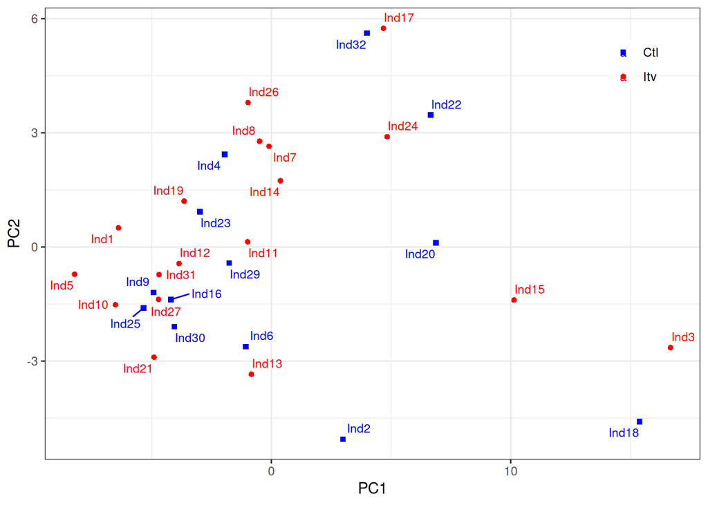

Gráfico das duas principais componentes em M2.

```r
gPca[[2]]
```

De forma semelhante, aqui também não há uma clusterização clara entre Controle e Intervenção.

Resolvemos, assim realizar nova nálise dos dados excluindo aqueles pacientes que tiveram uma variância nos dados maior que os demais na PCA das médias.

# Refazendo a análise excluindo outliers

Foram excluidas as amostras amostras dos pacientes Ind2, Ind6, Ind9, Ind11, Ind13, Ind14, Ind16, Ind17, Ind22 e Ind23, consederados *outliers*. A seguir repetiu-se a análise feita anteriormente.

## Área do centro de pressão (CoP)

```r
# Obter medidas das médias
#excluindo amostras 'Ind6','Ind16','Ind9','Ind13','Ind11','Ind17','Ind2','Ind22','Ind14' e 'Ind23'
excluir<-c('Ind6','Ind16','Ind9','Ind13','Ind11','Ind17','Ind2','Ind22','Ind14','Ind23')
m1<-m1[!m1$id %in% excluir,]
m2<-m2[!m2$id %in% excluir,]
df_area <- obter_medias(m1, m2, meta_m1, meta_m2, "area_var")

# Formato longo para o teste da MANOVA
df_area_w <- df_area %>%
  pivot_wider(names_from = trat, values_from = "media_area_var")

# Modelo
modelo <- manova(
  cbind(
    log(juntos),
    log(semitandem),
    log(separados),
    log(tandem)
  ) ~ grupo*momento, data = df_area_w)

summary(modelo, test = "Wilks")
```

```
              Df  Wilks approx F num Df den Df Pr(>F)
grupo          1 0.9053  0.86304      4     33 0.4963
momento        1 0.8661  1.27550      4     33 0.2994
grupo:momento  1 0.9615  0.33031      4     33 0.8556
Residuals     36
```

### Comparações

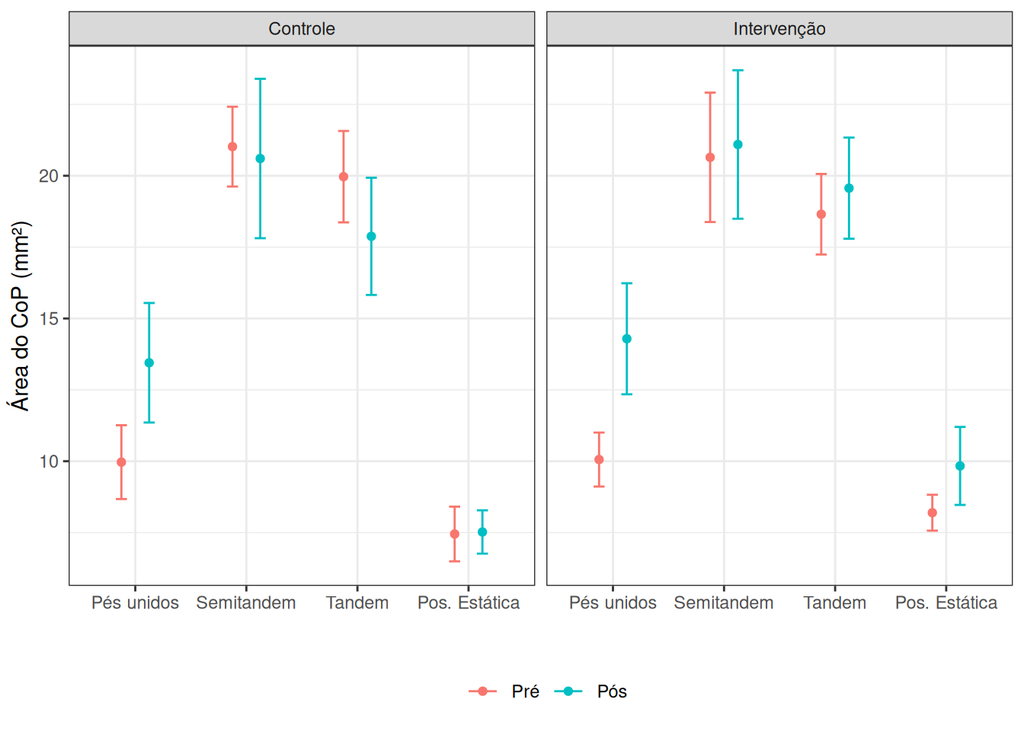

Variação da área do CoP. Cada ponto indica a média e as retas indicam o erro padrão.

```r
df_plot <- df_area %>%
  group_by(momento, grupo, trat) %>%
  summarise(media = mean(media_area_var, na.rm = T), desvio = se(media_area_var)) %>%
  ungroup() %>%
  mutate(momento = factor(momento, levels = c("Pré", "Pós")))

ggplot(df_plot) +
  geom_point(aes(x = trat, y = media, col = momento),
             position = position_dodge(width = 0.5)) +
  geom_errorbar(aes(x = trat, ymin = media-desvio, ymax = media+desvio, col = momento),
                position = position_dodge(width = 0.5), width = 0.2) +
  scale_x_discrete(limits = c("juntos", "semitandem", "tandem", "separados"),
                   labels = c("Pés unidos", "Semitandem", "Tandem", "Pos. Estática")) +
  facet_wrap(~grupo) +
  labs(x = "", y = "Área do CoP (mm²)", col = "") +
  theme_bw() +
  theme(legend.position = "bottom")
```

```r
# ggsave("output/figuras/biomecanica/area_cop.png", width = 7, height = 4, dpi = 300)
# ggsave("output/figuras/biomecanica/area_cop.svg", width = 7, height = 4, dpi = 300)
```

## Deslocamento da oscilação total (cm)

```r
# Obter medidas das médias
df_disp <- obter_medias(m1, m2, meta_m1, meta_m2, "disp")

# Formato longo para o teste da MANOVA
df_disp_w <- df_disp %>%
  pivot_wider(names_from = trat, values_from = "media_disp")

# Modelo
modelo <- manova(
  cbind(
    log(juntos),
    log(semitandem),
    log(separados),
    log(tandem)
  ) ~ grupo*momento, data = df_disp_w)

summary(modelo, test = "Wilks")
```

```
              Df   Wilks approx F num Df den Df   Pr(>F)
grupo          1 0.84377   1.5276      4     33 0.216919
momento        1 0.60482   5.3905      4     33 0.001875 **
grupo:momento  1 0.93080   0.6133      4     33 0.656024
Residuals     36
---
Signif. codes:  0 '***' 0.001 '**' 0.01 '*' 0.05 '.' 0.1 ' ' 1
```

### Comparações

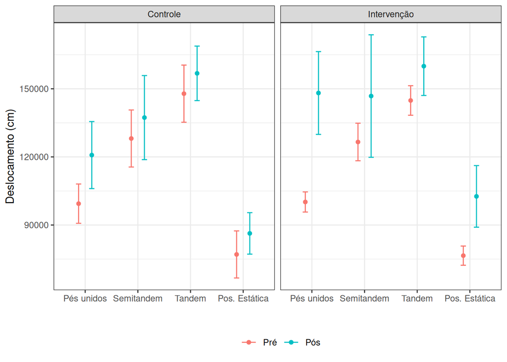

Deslocamento da ocilação total. Cada ponto indica a média e as retas indicam o erro padrão.

```r
df_plot <- df_disp %>%
  group_by(momento, grupo, trat) %>%
  summarise(media = mean(media_disp, na.rm = T), desvio = se(media_disp)) %>%
  ungroup() %>%
  mutate(momento = factor(momento, levels = c("Pré", "Pós")))

ggplot(df_plot) +
  geom_point(aes(x = trat, y = media, col = momento),
             position = position_dodge(width = 0.5)) +
  geom_errorbar(aes(x = trat, ymin = media-desvio, ymax = media+desvio, col = momento),
                position = position_dodge(width = 0.5), width = 0.2) +
  scale_x_discrete(limits = c("juntos", "semitandem", "tandem", "separados"),
                   labels = c("Pés unidos", "Semitandem", "Tandem", "Pos. Estática")) +
  facet_wrap(~grupo) +
  labs(x = "", y = "Deslocamento (cm)", col = "") +
  theme_bw() +
  theme(legend.position = "bottom")
```

```r
# ggsave("output/figuras/biomecanica/deslocamento.png", width = 7, height = 4, dpi = 300)
# ggsave("output/figuras/biomecanica/deslocamento.svg", width = 7, height = 4, dpi = 300)
```

## Amplitude medial-lateral (cm)

```r
# Obter medidas das médias
df_ampl_ml <- obter_medias(m1, m2, meta_m1, meta_m2, "ampl_ml")

# Formato longo para o teste da MANOVA
df_ampl_ml_w <- df_ampl_ml %>%
  pivot_wider(names_from = trat, values_from = "media_ampl_ml")

# Modelo
modelo <- manova(
  cbind(
    log(juntos),
    log(semitandem),
    log(separados),
    log(tandem)
  ) ~ grupo*momento, data = df_ampl_ml_w)

summary(modelo, test = "Wilks")
```

```
              Df   Wilks approx F num Df den Df  Pr(>F)
grupo          1 0.87816   1.1446      4     33 0.35285
momento        1 0.71202   3.3368      4     33 0.02118 *
grupo:momento  1 0.95598   0.3799      4     33 0.82137
Residuals     36
---
Signif. codes:  0 '***' 0.001 '**' 0.01 '*' 0.05 '.' 0.1 ' ' 1
```

### Comparações

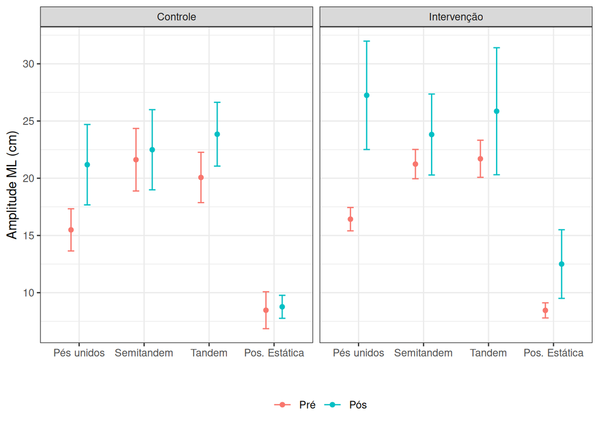

Amplitude medial-lateral (cm). Cada ponto indica a média e as retas indicam o erro padrão.

```r
df_plot <- df_ampl_ml %>%
  group_by(momento, grupo, trat) %>%
  summarise(media = mean(media_ampl_ml, na.rm = T), desvio = se(media_ampl_ml)) %>%
  ungroup() %>%
  mutate(momento = factor(momento, levels = c("Pré", "Pós")))

ggplot(df_plot) +
  geom_point(aes(x = trat, y = media, col = momento),
             position = position_dodge(width = 0.5)) +
  geom_errorbar(aes(x = trat, ymin = media-desvio, ymax = media+desvio, col = momento),
                position = position_dodge(width = 0.5), width = 0.2) +
  scale_x_discrete(limits = c("juntos", "semitandem", "tandem", "separados"),
                   labels = c("Pés unidos", "Semitandem", "Tandem", "Pos. Estática")) +
  facet_wrap(~grupo) +
  labs(x = "", y = "Amplitude ML (cm)", col = "") +
  theme_bw() +
  theme(legend.position = "bottom")
```

## Amplitude ântero-posterior (cm)

```r
# Obter medidas das médias
df_ampl_ap <- obter_medias(m1, m2, meta_m1, meta_m2, "ampl_ap")

# Formato longo para o teste da MANOVA
df_ampl_ap_w <- df_ampl_ap %>%
  pivot_wider(names_from = trat, values_from = "media_ampl_ap")

# Modelo
modelo <- manova(
  cbind(
    log(juntos),
    log(semitandem),
    log(separados),
    log(tandem)
  ) ~ grupo*momento, data = df_ampl_ap_w)

summary(modelo, test = "Wilks")
```

```
              Df   Wilks approx F num Df den Df Pr(>F)
grupo          1 0.81179   1.9128      4     33 0.1316
momento        1 0.82822   1.7111      4     33 0.1710
grupo:momento  1 0.94723   0.4596      4     33 0.7648
Residuals     36
```

### Comparações

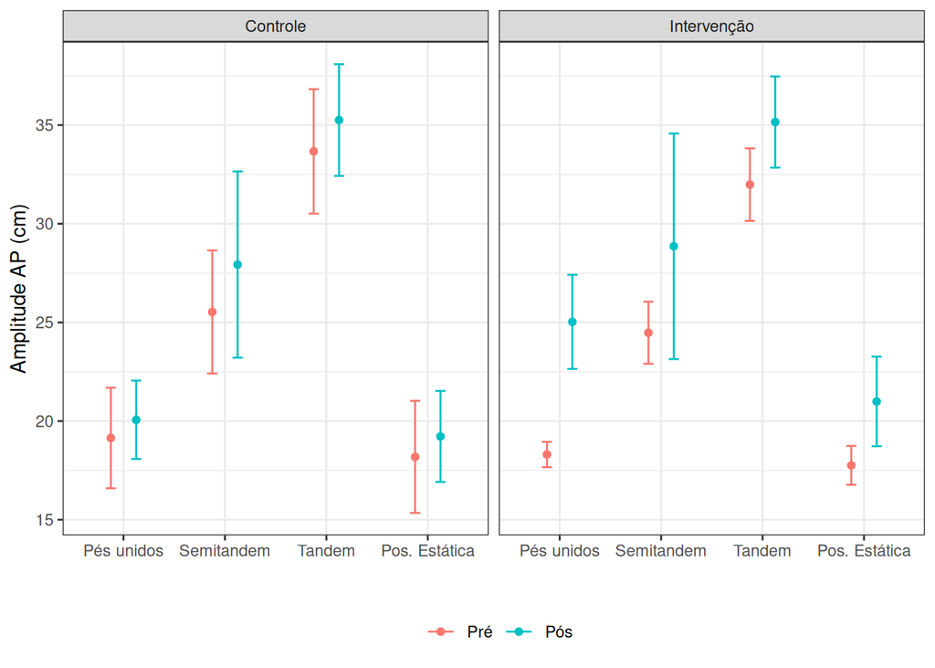

Amplitude ântero-posterior (cm). Cada ponto indica a média e as retas indicam o erro padrão.

```r
df_plot <- df_ampl_ap %>%
  group_by(momento, grupo, trat) %>%
  summarise(media = mean(media_ampl_ap, na.rm = T), desvio = se(media_ampl_ap)) %>%
  ungroup() %>%
  mutate(momento = factor(momento, levels = c("Pré", "Pós")))

ggplot(df_plot) +
  geom_point(aes(x = trat, y = media, col = momento),
             position = position_dodge(width = 0.5)) +
  geom_errorbar(aes(x = trat, ymin = media-desvio, ymax = media+desvio, col = momento),
                position = position_dodge(width = 0.5), width = 0.2) +
  scale_x_discrete(limits = c("juntos", "semitandem", "tandem", "separados"),
                   labels = c("Pés unidos", "Semitandem", "Tandem", "Pos. Estática")) +
  facet_wrap(~grupo) +
  labs(x = "", y = "Amplitude AP (cm)", col = "") +
  theme_bw() +
  theme(legend.position = "bottom")
```

```r
# ggsave("output/figuras/biomecanica/amplitude_ap.png", width = 7, height = 4, dpi = 300)
# ggsave("output/figuras/biomecanica/amplitude_ap.svg", width = 7, height = 4, dpi = 300)
```

## Velocidade média total (cm/s)

```r
# Obter medidas das médias
df_vel_media_total <- obter_medias(m1, m2, meta_m1, meta_m2, "vel_media_total")

# Formato longo para o teste da MANOVA
df_vel_media_total_w <- df_vel_media_total %>%
  pivot_wider(names_from = trat, values_from = "media_vel_media_total")

# Modelo
modelo <- manova(
  cbind(
    log(juntos),
    log(semitandem),
    log(separados),
    log(tandem)
  ) ~ grupo*momento, data = df_vel_media_total_w)

summary(modelo, test = "Wilks")
```

```
              Df   Wilks approx F num Df den Df Pr(>F)
grupo          1 0.85760  1.36987      4     33 0.2656
momento        1 0.75073  2.73934      4     33 0.0451 *
grupo:momento  1 0.93165  0.60528      4     33 0.6616
Residuals     36
---
Signif. codes:  0 '***' 0.001 '**' 0.01 '*' 0.05 '.' 0.1 ' ' 1
```

### Comparações

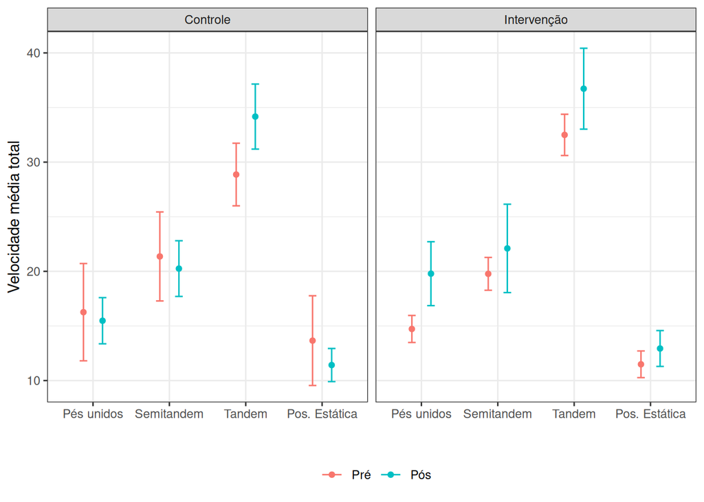

Velocidade média total (cm/s). Cada ponto indica a média e as retas indicam o erro padrão.

```r
df_plot <- df_vel_media_total %>%
  group_by(momento, grupo, trat) %>%
  summarise(media = mean(media_vel_media_total, na.rm = T), desvio = se(media_vel_media_total)) %>%
  ungroup() %>%
  mutate(momento = factor(momento, levels = c("Pré", "Pós")))

ggplot(df_plot) +
  geom_point(aes(x = trat, y = media, col = momento),
             position = position_dodge(width = 0.5)) +
  geom_errorbar(aes(x = trat, ymin = media-desvio, ymax = media+desvio, col = momento),
                position = position_dodge(width = 0.5), width = 0.2) +
  scale_x_discrete(limits = c("juntos", "semitandem", "tandem", "separados"),
                   labels = c("Pés unidos", "Semitandem", "Tandem", "Pos. Estática")) +
  facet_wrap(~grupo) +
  labs(x = "", y = "Velocidade média total", col = "") +
  theme_bw() +
  theme(legend.position = "bottom")
```

## Root mean square (RMS) medial-lateral

```r
# Obter medidas das médias
df_rms_ml <- obter_medias(m1, m2, meta_m1, meta_m2, "rms_ml")

# Formato longo para o teste da MANOVA
df_rms_ml_w <- df_rms_ml %>%
  pivot_wider(names_from = trat, values_from = "media_rms_ml")

# Modelo
modelo <- manova(
  cbind(
    log(juntos),
    log(semitandem),
    log(separados),
    log(tandem)
  ) ~ grupo*momento, data = df_rms_ml_w)

summary(modelo, test = "Wilks")
```

```
              Df   Wilks approx F num Df den Df  Pr(>F)
grupo          1 0.93318   0.5907      4     33 0.67170
momento        1 0.72169   3.1816      4     33 0.02572 *
grupo:momento  1 0.96117   0.3333      4     33 0.85353
Residuals     36
---
Signif. codes:  0 '***' 0.001 '**' 0.01 '*' 0.05 '.' 0.1 ' ' 1
```

### Comparações

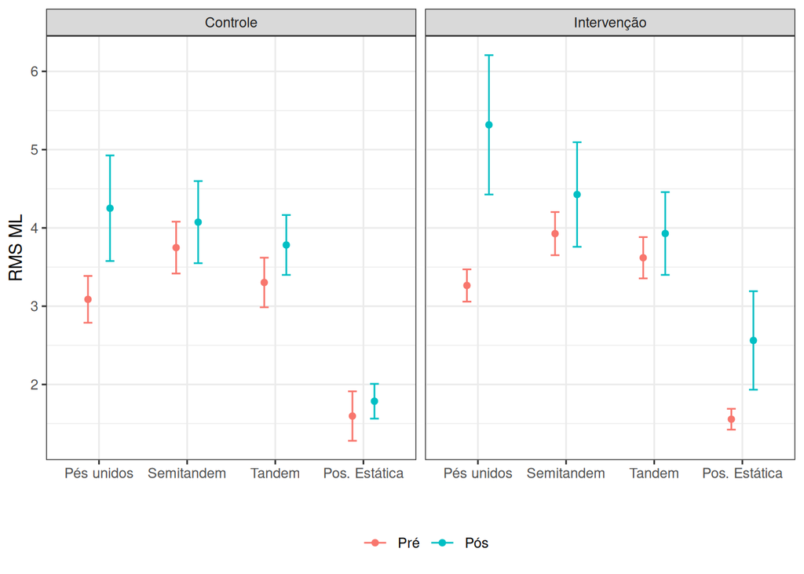

Root mean square (RMS) medial-lateral (cm/s). Cada ponto indica a média e as retas indicam o erro padrão.

```r
df_plot <- df_rms_ml %>%
  group_by(momento, grupo, trat) %>%
  summarise(media = mean(media_rms_ml, na.rm = T), desvio = se(media_rms_ml)) %>%
  ungroup() %>%
  mutate(momento = factor(momento, levels = c("Pré", "Pós")))

ggplot(df_plot) +
  geom_point(aes(x = trat, y = media, col = momento),
             position = position_dodge(width = 0.5)) +
  geom_errorbar(aes(x = trat, ymin = media-desvio, ymax = media+desvio, col = momento),
                position = position_dodge(width = 0.5), width = 0.2) +
  scale_x_discrete(limits = c("juntos", "semitandem", "tandem", "separados"),
                   labels = c("Pés unidos", "Semitandem", "Tandem", "Pos. Estática")) +
  facet_wrap(~grupo) +
  labs(x = "", y = "RMS ML", col = "") +
  theme_bw() +
  theme(legend.position = "bottom")
```

```r
# ggsave("output/figuras/biomecanica/rms_ml.png", width = 7, height = 4, dpi = 300)
# ggsave("output/figuras/biomecanica/rms_ml.svg", width = 7, height = 4, dpi = 300)
```

## Root mean square (RMS) ântero-posterior

```r
# Obter medidas das médias
df_rms_ap <- obter_medias(m1, m2, meta_m1, meta_m2, "rms_ap")

# Formato longo para o teste da MANOVA
df_rms_ap_w <- df_rms_ap %>%
  pivot_wider(names_from = trat, values_from = "media_rms_ap")

# Modelo
modelo <- manova(
  cbind(
    log(juntos),
    log(semitandem),
    log(separados),
    log(tandem)
  ) ~ grupo*momento, data = df_rms_ap_w)

summary(modelo, test = "Wilks")
```

```
              Df   Wilks approx F num Df den Df Pr(>F)
grupo          1 0.87101  1.22177      4     33 0.3204
momento        1 0.81054  1.92846      4     33 0.1289
grupo:momento  1 0.92956  0.62513      4     33 0.6479
Residuals     36
```

### Comparações

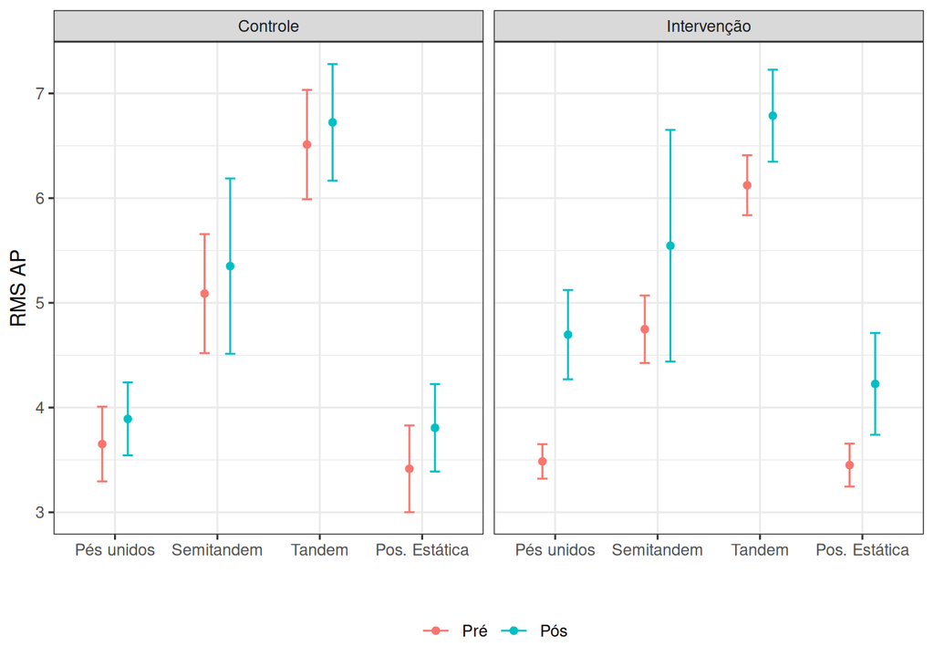

Root mean square (RMS) ântero-posterior (cm/s). Cada ponto indica a média e as retas indicam o erro padrão.

```r
df_plot <- df_rms_ap %>%
  group_by(momento, grupo, trat) %>%
  summarise(media = mean(media_rms_ap, na.rm = T), desvio = se(media_rms_ap)) %>%
  ungroup() %>%
  mutate(momento = factor(momento, levels = c("Pré", "Pós")))

ggplot(df_plot) +
  geom_point(aes(x = trat, y = media, col = momento),
             position = position_dodge(width = 0.5)) +
  geom_errorbar(aes(x = trat, ymin = media-desvio, ymax = media+desvio, col = momento),
                position = position_dodge(width = 0.5), width = 0.2) +
  scale_x_discrete(limits = c("juntos", "semitandem", "tandem", "separados"),
                   labels = c("Pés unidos", "Semitandem", "Tandem", "Pos. Estática")) +
  facet_wrap(~grupo) +
  labs(x = "", y = "RMS AP", col = "") +
  theme_bw() +
  theme(legend.position = "bottom")
```

```r
# ggsave("output/figuras/biomecanica/rms_ap.png", width = 7, height = 4, dpi = 300)
# ggsave("output/figuras/biomecanica/rms_ap.svg", width = 7, height = 4, dpi = 300)
```

# Resumo

Mais uma vez, não foi observada significância estatística para a interação entre grupos e momentos de coleta dos dados para as variáveis consideradas.

De fato, foi constatada uma menor variação nos dados, indicando que as discrepâncias entre os grupos Controle e Intervenção M2 eram causadas, principalmente pelos outliers, sendo o resultado de ambos os grupos bastante similares.